# 01

### **01-01. 행별 기대노출량**

### **01-02. 데모구간 노출량 분배**

## 01-01. 행별 기대노출량

### 01. 행별 데모타겟 인구모수 계산 (`pop_grps`)

- 행별 `gender`, `min`, `max` 값을 기반으로, `Population DB`를 참조하여 행별 데모타겟 인구모수 계산

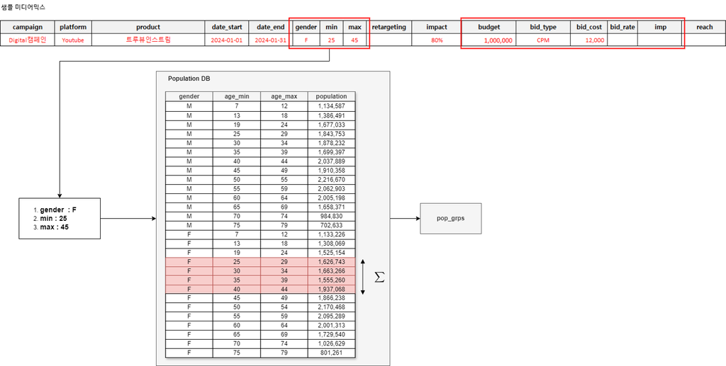

```python
mix_cleaned[['campaign', 'product', 'gender', 'min_org', 'max_org', 'bid_type', 'bid_cost', 'bid_rate', 'pop_grps']].\
    rename(columns={'min_org':'min', 'max_org':'max'})
```

|  | campaign | product | gender | min | max | bid_type | bid_cost | bid_rate | pop_grps |
| --- | --- | --- | --- | --- | --- | --- | --- | --- | --- |
| 0 | Digital캠페인 | 트루뷰인스트림 | F | 25 | 44 | CPM | 12000.0 | NaN | 6782337 |
| 1 | Digital캠페인 | 모바일 메인_배너 | F | 25 | 44 | CPC | 1000.0 | 0.0002 | 6782337 |
| 2 | Digital캠페인 | overall | P | 25 | 44 | E.IMP 직접입력 | NaN | NaN | 14241608 |
| 3 | Digital캠페인 | overall | P | 25 | 44 | 기집행 분석 (IMP) | NaN | NaN | 14241608 |
| 4 | TV캠페인 | overall | P | 25 | 44 | CPRP | 2500000.0 | NaN | 6782337 |
| 5 | TV캠페인 | 지상파 | P | 25 | 44 | E.GRP 직접입력 | NaN | NaN | 14241608 |
| 6 | TV캠페인 | 종편 | P | 25 | 44 | 기집행 분석 (GRP) | NaN | NaN | 14241608 |

### 02. 행별 기대 노출 수 계산

1. `bid_type` == `CPM`

$$\text{E.imp} = \frac{\text{budget}}{\text{bid_cost}} \times 1000$$

3. `bid_type` == `CPRP`

$$\text{E.imp} = \frac{\text{budget}}{\text{bid_cost}} \times \text{pop_grps} \div 100$$

4. `bid_type` == `E.GRP 직접입력`

$$\text{E.imp} = \frac{\text{imp}}{\text{100}} \times \text{pop_grps}$$

5. `bid_type` == `E.IMP 직접입력`

$$\text{E.imp} = \text{imp}$$

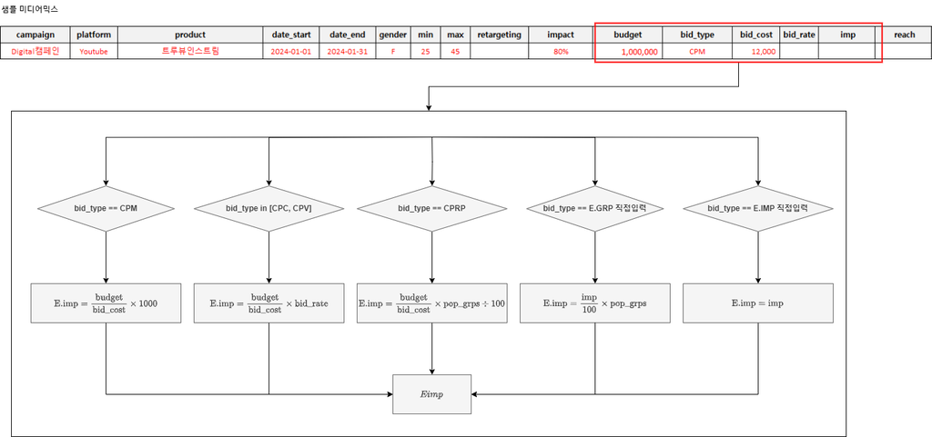

```python
mix_cleaned[['campaign', 'product', 'gender', 'min_org', 'max_org', 'bid_type', 'bid_cost', 'bid_rate', 'pop_grps', 'Eimp']].\
    rename(columns={'min_org':'min', 'max_org':'max'})
```

|  | campaign | product | gender | min | max | bid_type | bid_cost | bid_rate | pop_grps | Eimp |
| --- | --- | --- | --- | --- | --- | --- | --- | --- | --- | --- |
| 0 | Digital캠페인 | 트루뷰인스트림 | F | 25 | 44 | CPM | 12000.0 | NaN | 6782337 | 83333.333333 |
| 1 | Digital캠페인 | 모바일 메인_배너 | F | 25 | 44 | CPC | 1000.0 | 0.0002 | 6782337 | 5000000.0 |
| 2 | Digital캠페인 | overall | P | 25 | 44 | E.IMP 직접입력 | NaN | NaN | 14241608 | 2462332.0 |
| 3 | Digital캠페인 | overall | P | 25 | 44 | 기집행 분석 (IMP) | NaN | NaN | 14241608 | 0.0 |
| 4 | TV캠페인 | overall | P | 25 | 44 | CPRP | 2500000.0 | NaN | 6782337 | 77790858.755384 |
| 5 | TV캠페인 | 지상파 | P | 25 | 44 | E.GRP 직접입력 | NaN | NaN | 14241608 | 43435763.616646 |
| 6 | TV캠페인 | 종편 | P | 25 | 44 | 기집행 분석 (GRP) | NaN | NaN | 14241608 | 0.0 |

### 3. 인지효과 가중치 (`impact`) 반영

- $\text{eimp_weighted} = \text{impact} \times \text{E.imp}$

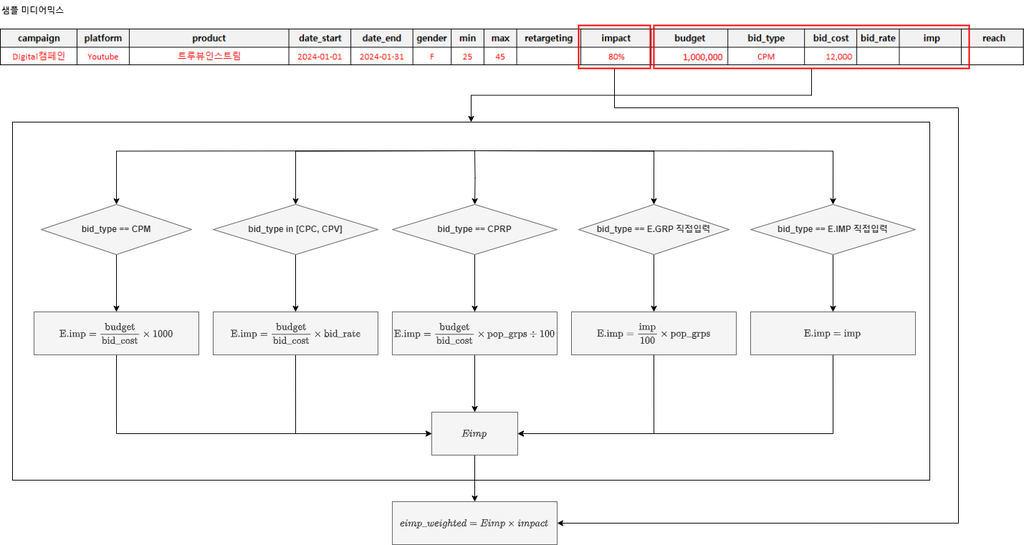

```python
mix_cleaned[['campaign', 'product', 'gender', 'min_org', 'max_org', 'bid_type', 'bid_cost', 'bid_rate', 'pop_grps', 'Eimp', 'impact', 'eimp_weighted']].\
    rename(columns={'min_org':'min', 'max_org':'max'})
```

|  | campaign | product | gender | min | max | bid_type | bid_cost | bid_rate | pop_grps | Eimp | impact | eimp_weighted |
| --- | --- | --- | --- | --- | --- | --- | --- | --- | --- | --- | --- | --- |
| 0 | Digital캠페인 | 트루뷰인스트림 | F | 25 | 44 | CPM | 12000.0 | NaN | 6782337 | 83333.333333 | 0.8 | 66666.666667 |
| 1 | Digital캠페인 | 모바일 메인_배너 | F | 25 | 44 | CPC | 1000.0 | 0.0002 | 6782337 | 5000000.0 | 0.2 | 1000000.0 |
| 2 | Digital캠페인 | overall | P | 25 | 44 | E.IMP 직접입력 | NaN | NaN | 14241608 | 2462332.0 | 0.5 | 1231166.0 |
| 3 | Digital캠페인 | overall | P | 25 | 44 | 기집행 분석 (IMP) | NaN | NaN | 14241608 | 0.0 | 1.0 | 0.0 |
| 4 | TV캠페인 | overall | P | 25 | 44 | CPRP | 2500000.0 | NaN | 6782337 | 77790858.755384 | 1.0 | 77790858.755384 |
| 5 | TV캠페인 | 지상파 | P | 25 | 44 | E.GRP 직접입력 | NaN | NaN | 14241608 | 43435763.616646 | 1.0 | 43435763.616646 |
| 6 | TV캠페인 | 종편 | P | 25 | 44 | 기집행 분석 (GRP) | NaN | NaN | 14241608 | 0.0 | 1.0 | 0.0 |

### 4. 논타겟 매체 (TV, SMR)에 대한 데모타겟 강제변환

- 논타겟 매체가 포함된 행에 대하여, `gender` `min`, `max`의 값들을 각각 'P', 7 , 79로 변환

(`gender_org`, `min_org`, `max_org`는 입력된 `gender` `min`, `max` 원래 값)

```python
mix_cleaned[['campaign', 'platform', 'product', 'gender_org', 'min_org', 'max_org', 'gender', 'min', 'max']]
```

|  | campaign | platform | product | gender_org | min_org | max_org | gender | min | max |
| --- | --- | --- | --- | --- | --- | --- | --- | --- | --- |
| 0 | Digital캠페인 | Youtube | 트루뷰인스트림 | F | 25 | 44 | F | 25 | 44 |
| 1 | Digital캠페인 | GFA | 모바일 메인_배너 | F | 25 | 44 | F | 25 | 44 |
| 2 | Digital캠페인 | SMR | overall | P | 25 | 44 | P | 7 | 79 |
| 3 | Digital캠페인 | Kakao | overall | P | 25 | 44 | P | 25 | 44 |
| 4 | TV캠페인 | TV | overall | F | 25 | 44 | P | 7 | 79 |
| 5 | TV캠페인 | TV | 지상파 | P | 25 | 44 | P | 7 | 79 |
| 6 | TV캠페인 | TV | 종편 | P | 25 | 44 | P | 7 | 79 |

### 5. 기집행 노출수/도달수 계산 (`Aimp`, `Areach`)

1. `bid_type` == `기집행 분석 (IMP)`

$$\text{Aimp} = \text{imp}$$$$\text{Areach} = \text{reach}$$

2. `bid_type` == `기집행 분석 (GRP)`

$$\text{Aimp} = \text{imp} \times \text{pop_grps} \div 100$$$$\text{Areach} = \text{reach} \times \text{pop_grps}$$

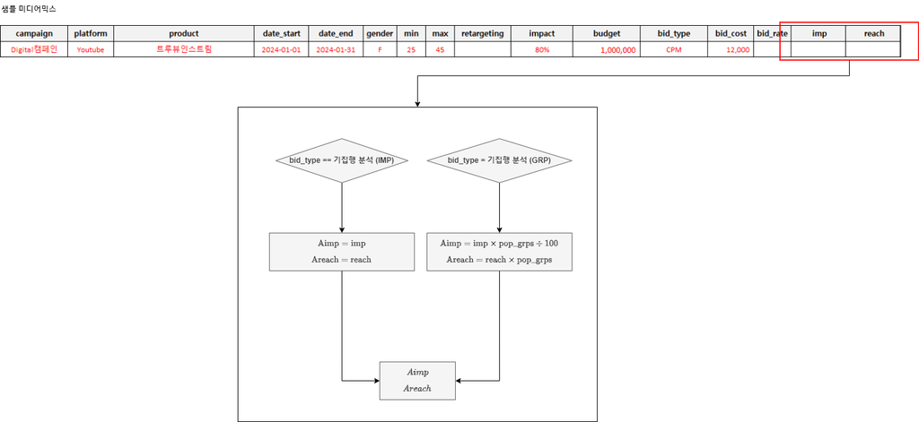

```python
mix_cleaned[['campaign', 'platform', 'product', 'bid_type', 'Aimp', 'Areach']]
```

|  | campaign | platform | product | bid_type | Aimp | Areach |
| --- | --- | --- | --- | --- | --- | --- |
| 0 | Digital캠페인 | Youtube | 트루뷰인스트림 | CPM | 0.0 | 0.0 |
| 1 | Digital캠페인 | GFA | 모바일 메인_배너 | CPC | 0.0 | 0.0 |
| 2 | Digital캠페인 | SMR | overall | E.IMP 직접입력 | 0.0 | 0.0 |
| 3 | Digital캠페인 | Kakao | overall | 기집행 분석 (IMP) | 1379671.0 | 885760.0 |
| 4 | TV캠페인 | TV | overall | CPRP | 0.0 | 0.0 |
| 5 | TV캠페인 | TV | 지상파 | E.GRP 직접입력 | 0.0 | 0.0 |
| 6 | TV캠페인 | TV | 종편 | 기집행 분석 (GRP) | 51192149.976761 | 19374415.10025 |

### 6. TV매체 노출수/도달수 계산 (2) : 모든 TV매체 행에 대한 기집행 노출수/도달수 분배

### 하나의 행을 모든 인구구간 (28개) 단위로 분해

1. TV매체는 논타겟 매체로서, 데모타겟이 P0779로 강제변환 됨

   $\rightarrow$ 원래의 데모타겟 구간에 대해서 `Distribution DB`를 참조하여, 인구비율에 맞게 이전에 계산된 `E.imp`, `eimp_weighted`, `Aimp`를 분배

   $\rightarrow$ 원래의 데모타겟 구간이 아닌 인구구간에 대해서도 `Distribution DB`를 참조하여,

   $({\text{원래의 인구구간이 아닌 각 구간의 인구수}}) \div ({\text{원래의 데모타겟 구간 인구총합}})$의 비율에 맞게 분배

   ***(TV는 데모타겟이 아닌 인구구간에도 노출이 발생하는 매체라는 가정)***
- `a_imp` 인구구간별로 분배된 `Aimp`

```python
df.drop(['campaign', 'aimp_weighted', 'impact', 'date', 'line', 'age', 'max_org', 'min_org',], axis=1).\
    filter(['platform', 'product', 'gender', 'age_min', 'age_max', 'population', 'isDemo', 'distribution', 'Eimp', 'a_imp'])
```

|  | platform | product | gender | age_min | age_max | population | isDemo | distribution | Eimp | a_imp |
| --- | --- | --- | --- | --- | --- | --- | --- | --- | --- | --- |
| 0 | TV | 종편 | M | 7 | 12 | 1134587 | 0 | 0.020794 | 0.0 | 5.797403e+06 |
| 1 | TV | 종편 | M | 13 | 18 | 1386491 | 0 | 0.003607 | 0.0 | 1.005789e+06 |
| 2 | TV | 종편 | M | 19 | 24 | 1677033 | 0 | 0.006521 | 0.0 | 1.818080e+06 |
| 3 | TV | 종편 | M | 25 | 29 | 1843753 | 1 | 0.014396 | 0.0 | 4.013805e+06 |
| 4 | TV | 종편 | M | 30 | 34 | 1878232 | 1 | 0.016083 | 0.0 | 4.484171e+06 |
| 5 | TV | 종편 | M | 35 | 39 | 1699397 | 1 | 0.020161 | 0.0 | 5.620953e+06 |
| 6 | TV | 종편 | M | 40 | 44 | 2037889 | 1 | 0.028347 | 0.0 | 7.903263e+06 |
| 7 | TV | 종편 | M | 45 | 49 | 1910358 | 0 | 0.040788 | 0.0 | 1.137207e+07 |
| 8 | TV | 종편 | M | 50 | 54 | 2216670 | 0 | 0.056086 | 0.0 | 1.563713e+07 |
| 9 | TV | 종편 | M | 55 | 59 | 2062903 | 0 | 0.050386 | 0.0 | 1.404788e+07 |
| 10 | TV | 종편 | M | 60 | 64 | 2005198 | 0 | 0.052454 | 0.0 | 1.462448e+07 |
| 11 | TV | 종편 | M | 65 | 69 | 1658371 | 0 | 0.054221 | 0.0 | 1.511721e+07 |
| 12 | TV | 종편 | M | 70 | 74 | 984830 | 0 | 0.035283 | 0.0 | 9.837205e+06 |
| 13 | TV | 종편 | M | 75 | 79 | 702633 | 0 | 0.024817 | 0.0 | 6.919281e+06 |
| 14 | TV | 종편 | F | 7 | 12 | 1133226 | 0 | 0.017131 | 0.0 | 4.776110e+06 |
| 15 | TV | 종편 | F | 13 | 18 | 1308069 | 0 | 0.005489 | 0.0 | 1.530252e+06 |
| 16 | TV | 종편 | F | 19 | 24 | 1525154 | 0 | 0.009236 | 0.0 | 2.575184e+06 |
| 17 | TV | 종편 | F | 25 | 29 | 1626743 | 1 | 0.014174 | 0.0 | 3.951898e+06 |
| 18 | TV | 종편 | F | 30 | 34 | 1663266 | 1 | 0.014746 | 0.0 | 4.111200e+06 |
| 19 | TV | 종편 | F | 35 | 39 | 1555260 | 1 | 0.032766 | 0.0 | 9.135259e+06 |
| 20 | TV | 종편 | F | 40 | 44 | 1937068 | 1 | 0.042939 | 0.0 | 1.197160e+07 |
| 21 | TV | 종편 | F | 45 | 49 | 1866238 | 0 | 0.063674 | 0.0 | 1.775268e+07 |
| 22 | TV | 종편 | F | 50 | 54 | 2170468 | 0 | 0.071271 | 0.0 | 1.987095e+07 |
| 23 | TV | 종편 | F | 55 | 59 | 2095289 | 0 | 0.064845 | 0.0 | 1.807929e+07 |
| 24 | TV | 종편 | F | 60 | 64 | 2001313 | 0 | 0.070803 | 0.0 | 1.974049e+07 |
| 25 | TV | 종편 | F | 65 | 69 | 1729540 | 0 | 0.075435 | 0.0 | 2.103187e+07 |
| 26 | TV | 종편 | F | 70 | 74 | 1026629 | 0 | 0.052558 | 0.0 | 1.465360e+07 |
| 27 | TV | 종편 | F | 75 | 79 | 801261 | 0 | 0.040989 | 0.0 | 1.142796e+07 |

2. 행의 `bid_type`이 `기집행 분석 (GRP)`일 경우,

   $\rightarrow$ 모든 인구구간별로 분배된 `Aimp`와 인구모수를 기반으로 $GRP$계산

   $\rightarrow$ `Parameter DB`를 참조하여, 행의 `platform`, `product` 인구구간에 해당하는 `a`, `b`, `c`계수를 추출

   $\rightarrow$ 계산된 GRP와, `a`, `b`, `c`를 기반으로각 인구구간별 도달률 및 도달수 계산 ($= \frac{c}{1 + exp(-(a + b \times \text{ln}(GRP))}$)

   $\rightarrow$ '계산된 인구구간별 도달수 총합과', '원래 입력된 행의 기집행 도달'의 비율을 계산 하여,

   계산된 각 인구구간별 도달에 곱하여 보정 $\rightarrow$ **원래 입력된 행의 기집행 도달과 동일하게 맞추기 위함**
3. [2.]에서 보정된 각 인구구간별 도달수의 총합을, 각 행의 기집행 도달수로,

   [1.]에서 각 인구구간별 분배된 기대 노출수의 총합을, 각 행의 기대 노출수로 대체

   [1.]에서 각 인구구간별 분배된 기집행 노출수의 총합을, 각 행의 기집행 노출수로 대체
4. [1. ~ 3.]의 과정을 모든 TV매체 행에 적용 후,

   TV가 아닌 매체의 행들과 결합

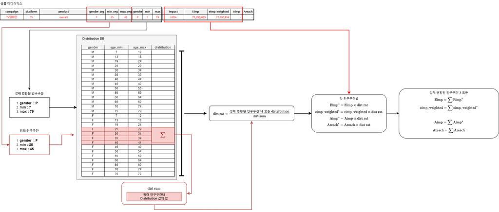

#### **위 절차를 통하여 각 TV매체 행은, 강제변환된 P0779 데모타겟에 대해, 기대 노출량 / 기집행 노출량 / 기집행 도달수를 가지게 되며,**

**해당 값들은 원래 입력 되었던 TV매체의 데모타겟구간에 대해서도, 원래 입력된 기대 노출량 / 기집행 노출량 / 기집행 도달량과 동일한 값을 가지게 됨**

```python
mix_cleaned.iloc[:, :17].drop(['date_start', 'date_end'], axis=1)
```

|  | campaign | platform | product | gender | min | max | retargeting | impact | budget | bid_type | bid_cost | bid_rate | Eimp | Aimp | Areach |
| --- | --- | --- | --- | --- | --- | --- | --- | --- | --- | --- | --- | --- | --- | --- | --- |
| 0 | Digital캠페인 | Youtube | 트루뷰인스트림 | F | 25 | 44 | NaN | 0.8 | 1000000.0 | CPM | 12000.0 | NaN | 83333.333333 | 0.0 | 0.0 |
| 1 | Digital캠페인 | GFA | 모바일 메인_배너 | F | 25 | 44 | 300000.0 | 0.2 | 1000000.0 | CPC | 1000.0 | 0.0002 | 5000000.0 | 0.0 | 0.0 |
| 2 | Digital캠페인 | SMR | overall | P | 7 | 79 | NaN | 0.5 | 5000000.0 | E.IMP 직접입력 | NaN | NaN | 2462332.0 | 0.0 | 0.0 |
| 3 | Digital캠페인 | Kakao | overall | P | 25 | 44 | None | 1.0 | 6000000.0 | 기집행 분석 (IMP) | NaN | NaN | 0.0 | 1379671.0 | 885760.0 |
| 4 | TV캠페인 | TV | overall | P | 7 | 79 | None | 1.0 | 300000000.0 | CPRP | 2500000.0 | NaN | 77790858.755384 | 0.0 | 0.0 |
| 5 | TV캠페인 | TV | 지상파 | P | 7 | 79 | None | 1.0 | 300000000.0 | E.GRP 직접입력 | NaN | NaN | 43435763.616646 | 0.0 | 0.0 |
| 6 | TV캠페인 | TV | 종편 | P | 7 | 79 | None | 1.0 | 300000000.0 | 기집행 분석 (GRP) | NaN | NaN | 0.0 | 51192149.976761 | 19374415.10025 |

```python
mix_cleaned[['campaign', 'product', 'gender', 'min_org', 'max_org', 'bid_type', 'bid_cost', 'bid_rate', 'pop_grps', 'Eimp', 'impact', 'eimp_weighted', 'Aimp', 'Areach']].\
    rename(columns={'min_org':'min', 'max_org':'max'})
```

|  | campaign | product | gender | min | max | bid_type | bid_cost | bid_rate | pop_grps | Eimp | impact | eimp_weighted | Aimp | Areach |
| --- | --- | --- | --- | --- | --- | --- | --- | --- | --- | --- | --- | --- | --- | --- |
| 0 | Digital캠페인 | 트루뷰인스트림 | F | 25 | 44 | CPM | 12000.0 | NaN | 6782337 | 83333.333333 | 0.8 | 66666.666667 | 0.0 | 0.0 |
| 1 | Digital캠페인 | 모바일 메인_배너 | F | 25 | 44 | CPC | 1000.0 | 0.0002 | 6782337 | 5000000.0 | 0.2 | 1000000.0 | 0.0 | 0.0 |
| 2 | Digital캠페인 | overall | P | 25 | 44 | E.IMP 직접입력 | NaN | NaN | 14241608 | 2462332.0 | 0.5 | 1231166.0 | 0.0 | 0.0 |
| 3 | Digital캠페인 | overall | P | 25 | 44 | 기집행 분석 (IMP) | NaN | NaN | 14241608 | 0.0 | 1.0 | 0.0 | 1379671.0 | 885760.0 |
| 4 | TV캠페인 | overall | P | 25 | 44 | CPRP | 2500000.0 | NaN | 6782337 | 77790858.755384 | 1.0 | 77790858.755384 | 0.0 | 0.0 |
| 5 | TV캠페인 | 지상파 | P | 25 | 44 | E.GRP 직접입력 | NaN | NaN | 14241608 | 43435763.616646 | 1.0 | 43435763.616646 | 0.0 | 0.0 |
| 6 | TV캠페인 | 종편 | P | 25 | 44 | 기집행 분석 (GRP) | NaN | NaN | 14241608 | 0.0 | 1.0 | 0.0 | 51192149.976761 | 19374415.10025 |

## 01-02. 데모구간 노출수 분배

### 01. 기대노출량이 계산된 미디어믹스의 모든 행에 대하여, 28개 인구구간 단위로 분해한 후 `Population DB`, `Distribution DB`, `Parameter DB`와 병합 (Merge)

- `population` : 모든 인구구간별 인구수 (`Population DB` 참조)
- `dist` : 행의 데모타겟에 해당하는 인구구간에 대해, `platform`에 해당하는 매체의 MAU 비율 (`Distribution DB` 참조)
- `a` / `b` / `c` : 행의 `platform`, `product`과 각 인구구간에 해당하는 예측 모델 회귀계수 (`Parameter DB` 참조)
- `a_ovr` / `b_ovr` / `c_ovr` : 행의 `platform`에 해당하는 예측 모델 회귀계수 중 `product`가 `subtotal`인 모델의 회귀계수 (`Parameter DB` 참조)

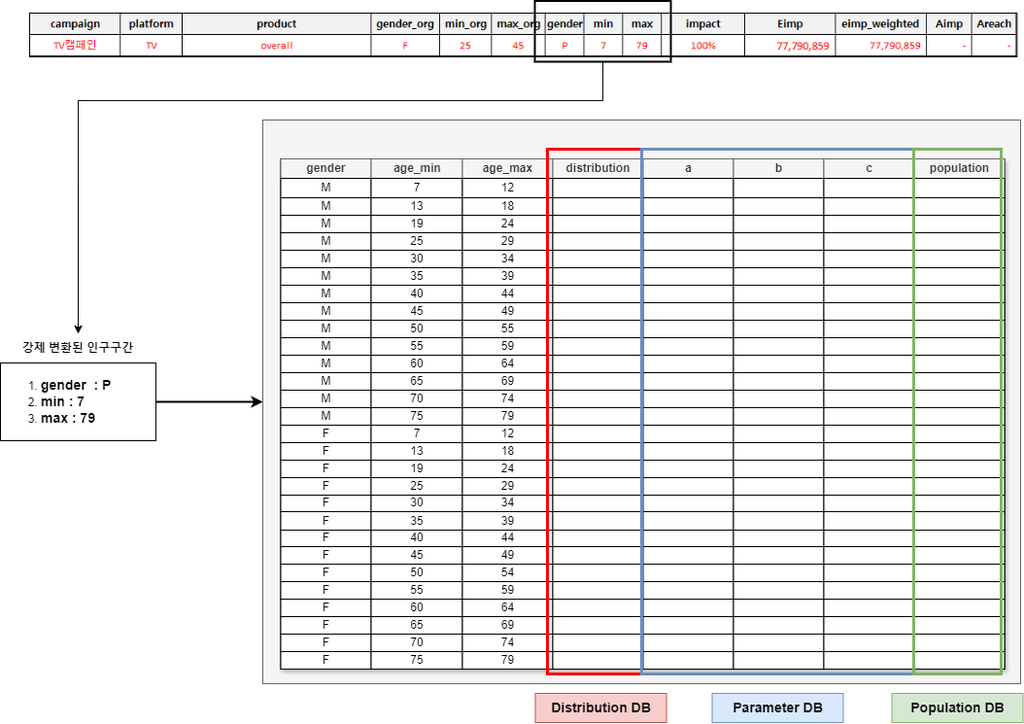

```python
df.head(28)[['platform', 'product', 'gender', 'age_min', 'age_max', 'population', 'dist', 'a', 'b', 'c', 'a_ovr', 'b_ovr', 'c_ovr']]
```

|  | platform | product | gender | age_min | age_max | population | dist | a | b | c | a_ovr | b_ovr | c_ovr |
| --- | --- | --- | --- | --- | --- | --- | --- | --- | --- | --- | --- | --- | --- |
| 0 | Youtube | 트루뷰인스트림 | M | 7 | 12 | 1134587 | 0.000000 | 0.000000 | 0.000000 | 0.000000 | 0.000000 | 0.000000 | 0.000000 |
| 1 | Youtube | 트루뷰인스트림 | M | 13 | 18 | 1386491 | 0.000000 | 0.000000 | 0.000000 | 0.000000 | 0.000000 | 0.000000 | 0.000000 |
| 2 | Youtube | 트루뷰인스트림 | M | 19 | 24 | 1677033 | 0.000000 | 0.000000 | 0.000000 | 0.000000 | 0.000000 | 0.000000 | 0.000000 |
| 3 | Youtube | 트루뷰인스트림 | M | 25 | 29 | 1843753 | 0.000000 | 0.000000 | 0.000000 | 0.000000 | 0.000000 | 0.000000 | 0.000000 |
| 4 | Youtube | 트루뷰인스트림 | M | 30 | 34 | 1878232 | 0.000000 | 0.000000 | 0.000000 | 0.000000 | 0.000000 | 0.000000 | 0.000000 |
| 5 | Youtube | 트루뷰인스트림 | M | 35 | 39 | 1699397 | 0.000000 | 0.000000 | 0.000000 | 0.000000 | 0.000000 | 0.000000 | 0.000000 |
| 6 | Youtube | 트루뷰인스트림 | M | 40 | 44 | 2037889 | 0.000000 | 0.000000 | 0.000000 | 0.000000 | 0.000000 | 0.000000 | 0.000000 |
| 7 | Youtube | 트루뷰인스트림 | M | 45 | 49 | 1910358 | 0.000000 | 0.000000 | 0.000000 | 0.000000 | 0.000000 | 0.000000 | 0.000000 |
| 8 | Youtube | 트루뷰인스트림 | M | 50 | 54 | 2216670 | 0.000000 | 0.000000 | 0.000000 | 0.000000 | 0.000000 | 0.000000 | 0.000000 |
| 9 | Youtube | 트루뷰인스트림 | M | 55 | 59 | 2062903 | 0.000000 | 0.000000 | 0.000000 | 0.000000 | 0.000000 | 0.000000 | 0.000000 |
| 10 | Youtube | 트루뷰인스트림 | M | 60 | 64 | 2005198 | 0.000000 | 0.000000 | 0.000000 | 0.000000 | 0.000000 | 0.000000 | 0.000000 |
| 11 | Youtube | 트루뷰인스트림 | M | 65 | 69 | 1658371 | 0.000000 | 0.000000 | 0.000000 | 0.000000 | 0.000000 | 0.000000 | 0.000000 |
| 12 | Youtube | 트루뷰인스트림 | M | 70 | 74 | 984830 | 0.000000 | 0.000000 | 0.000000 | 0.000000 | 0.000000 | 0.000000 | 0.000000 |
| 13 | Youtube | 트루뷰인스트림 | M | 75 | 79 | 702633 | 0.000000 | 0.000000 | 0.000000 | 0.000000 | 0.000000 | 0.000000 | 0.000000 |
| 14 | Youtube | 트루뷰인스트림 | F | 7 | 12 | 1133226 | 0.000000 | 0.000000 | 0.000000 | 0.000000 | 0.000000 | 0.000000 | 0.000000 |
| 15 | Youtube | 트루뷰인스트림 | F | 13 | 18 | 1308069 | 0.000000 | 0.000000 | 0.000000 | 0.000000 | 0.000000 | 0.000000 | 0.000000 |
| 16 | Youtube | 트루뷰인스트림 | F | 19 | 24 | 1525154 | 0.000000 | 0.000000 | 0.000000 | 0.000000 | 0.000000 | 0.000000 | 0.000000 |
| 17 | Youtube | 트루뷰인스트림 | F | 25 | 29 | 1626743 | 0.250199 | -5.127594 | 1.003162 | 0.982852 | -4.496451 | 0.863235 | 0.982852 |
| 18 | Youtube | 트루뷰인스트림 | F | 30 | 34 | 1663266 | 0.236289 | -5.127594 | 1.003162 | 0.907826 | -4.560273 | 0.797815 | 0.907826 |
| 19 | Youtube | 트루뷰인스트림 | F | 35 | 39 | 1555260 | 0.229476 | -5.127594 | 1.003162 | 0.942878 | -4.692378 | 0.893137 | 0.942878 |
| 20 | Youtube | 트루뷰인스트림 | F | 40 | 44 | 1937068 | 0.284036 | -5.127594 | 1.003162 | 0.937021 | -4.625659 | 0.880073 | 0.937021 |
| 21 | Youtube | 트루뷰인스트림 | F | 45 | 49 | 1866238 | 0.000000 | 0.000000 | 0.000000 | 0.000000 | 0.000000 | 0.000000 | 0.000000 |
| 22 | Youtube | 트루뷰인스트림 | F | 50 | 54 | 2170468 | 0.000000 | 0.000000 | 0.000000 | 0.000000 | 0.000000 | 0.000000 | 0.000000 |
| 23 | Youtube | 트루뷰인스트림 | F | 55 | 59 | 2095289 | 0.000000 | 0.000000 | 0.000000 | 0.000000 | 0.000000 | 0.000000 | 0.000000 |
| 24 | Youtube | 트루뷰인스트림 | F | 60 | 64 | 2001313 | 0.000000 | 0.000000 | 0.000000 | 0.000000 | 0.000000 | 0.000000 | 0.000000 |
| 25 | Youtube | 트루뷰인스트림 | F | 65 | 69 | 1729540 | 0.000000 | 0.000000 | 0.000000 | 0.000000 | 0.000000 | 0.000000 | 0.000000 |
| 26 | Youtube | 트루뷰인스트림 | F | 70 | 74 | 1026629 | 0.000000 | 0.000000 | 0.000000 | 0.000000 | 0.000000 | 0.000000 | 0.000000 |
| 27 | Youtube | 트루뷰인스트림 | F | 75 | 79 | 801261 | 0.000000 | 0.000000 | 0.000000 | 0.000000 | 0.000000 | 0.000000 | 0.000000 |

### 02. 노출수 분배

- **각 행별 강제변환된 인구구간에 대하여**
  - `Eimp` : 가중치 미적용 기대 노출수 `Eimp` X `dist`
  - `emip_weighted` : 가중치가 적용된 기대 노출수 `eimp_weighted` X `dist`
  - `Aimp` : 기집행 노출수 `Aimp` X `dist`
  - `retargeting` : 각 행별 입력된 리타겟팅 모수 X `dist`
- **각 행별 강제 변환된 인구구간에 미포함시 모든 값은 0**

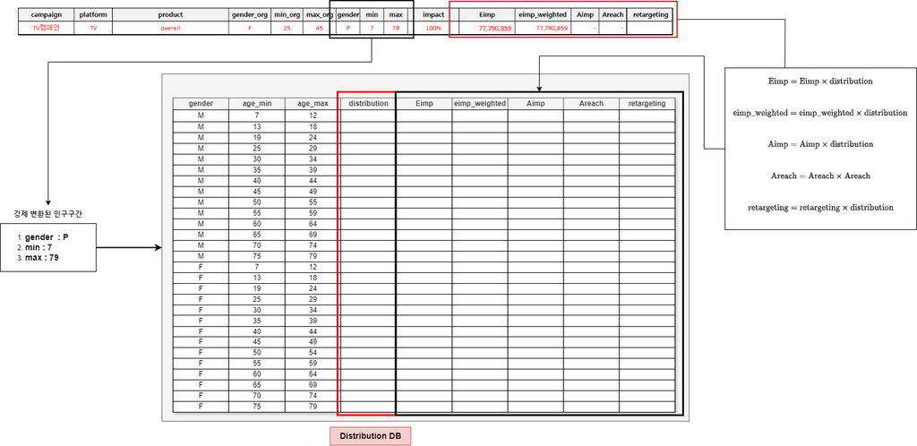

```python
df.head(56).tail(28)[['line', 'platform', 'product', 'gender', 'age_min', 'age_max', 'Eimp', 'eimp_weighted', 'Aimp', 'retargeting']]
```

|  | line | platform | product | gender | age_min | age_max | Eimp | eimp_weighted | Aimp | retargeting |
| --- | --- | --- | --- | --- | --- | --- | --- | --- | --- | --- |
| 0 | 2 | GFA | 모바일 메인_배너 | M | 7 | 12 | 0.000000e+00 | 0.000000 | 0.0 | 0.000000 |
| 1 | 2 | GFA | 모바일 메인_배너 | M | 13 | 18 | 0.000000e+00 | 0.000000 | 0.0 | 0.000000 |
| 2 | 2 | GFA | 모바일 메인_배너 | M | 19 | 24 | 0.000000e+00 | 0.000000 | 0.0 | 0.000000 |
| 3 | 2 | GFA | 모바일 메인_배너 | M | 25 | 29 | 0.000000e+00 | 0.000000 | 0.0 | 0.000000 |
| 4 | 2 | GFA | 모바일 메인_배너 | M | 30 | 34 | 0.000000e+00 | 0.000000 | 0.0 | 0.000000 |
| 5 | 2 | GFA | 모바일 메인_배너 | M | 35 | 39 | 0.000000e+00 | 0.000000 | 0.0 | 0.000000 |
| 6 | 2 | GFA | 모바일 메인_배너 | M | 40 | 44 | 0.000000e+00 | 0.000000 | 0.0 | 0.000000 |
| 7 | 2 | GFA | 모바일 메인_배너 | M | 45 | 49 | 0.000000e+00 | 0.000000 | 0.0 | 0.000000 |
| 8 | 2 | GFA | 모바일 메인_배너 | M | 50 | 54 | 0.000000e+00 | 0.000000 | 0.0 | 0.000000 |
| 9 | 2 | GFA | 모바일 메인_배너 | M | 55 | 59 | 0.000000e+00 | 0.000000 | 0.0 | 0.000000 |
| 10 | 2 | GFA | 모바일 메인_배너 | M | 60 | 64 | 0.000000e+00 | 0.000000 | 0.0 | 0.000000 |
| 11 | 2 | GFA | 모바일 메인_배너 | M | 65 | 69 | 0.000000e+00 | 0.000000 | 0.0 | 0.000000 |
| 12 | 2 | GFA | 모바일 메인_배너 | M | 70 | 74 | 0.000000e+00 | 0.000000 | 0.0 | 0.000000 |
| 13 | 2 | GFA | 모바일 메인_배너 | M | 75 | 79 | 0.000000e+00 | 0.000000 | 0.0 | 0.000000 |
| 14 | 2 | GFA | 모바일 메인_배너 | F | 7 | 12 | 0.000000e+00 | 0.000000 | 0.0 | 0.000000 |
| 15 | 2 | GFA | 모바일 메인_배너 | F | 13 | 18 | 0.000000e+00 | 0.000000 | 0.0 | 0.000000 |
| 16 | 2 | GFA | 모바일 메인_배너 | F | 19 | 24 | 0.000000e+00 | 0.000000 | 0.0 | 0.000000 |
| 17 | 2 | GFA | 모바일 메인_배너 | F | 25 | 29 | 1.174451e+06 | 234890.209577 | 0.0 | 70467.062873 |
| 18 | 2 | GFA | 모바일 메인_배너 | F | 30 | 34 | 1.206228e+06 | 241245.685798 | 0.0 | 72373.705739 |
| 19 | 2 | GFA | 모바일 메인_배너 | F | 35 | 39 | 1.161925e+06 | 232385.083615 | 0.0 | 69715.525084 |
| 20 | 2 | GFA | 모바일 메인_배너 | F | 40 | 44 | 1.457395e+06 | 291479.021011 | 0.0 | 87443.706303 |
| 21 | 2 | GFA | 모바일 메인_배너 | F | 45 | 49 | 0.000000e+00 | 0.000000 | 0.0 | 0.000000 |
| 22 | 2 | GFA | 모바일 메인_배너 | F | 50 | 54 | 0.000000e+00 | 0.000000 | 0.0 | 0.000000 |
| 23 | 2 | GFA | 모바일 메인_배너 | F | 55 | 59 | 0.000000e+00 | 0.000000 | 0.0 | 0.000000 |
| 24 | 2 | GFA | 모바일 메인_배너 | F | 60 | 64 | 0.000000e+00 | 0.000000 | 0.0 | 0.000000 |
| 25 | 2 | GFA | 모바일 메인_배너 | F | 65 | 69 | 0.000000e+00 | 0.000000 | 0.0 | 0.000000 |
| 26 | 2 | GFA | 모바일 메인_배너 | F | 70 | 74 | 0.000000e+00 | 0.000000 | 0.0 | 0.000000 |
| 27 | 2 | GFA | 모바일 메인_배너 | F | 75 | 79 | 0.000000e+00 | 0.000000 | 0.0 | 0.000000 |